# 2022.11.1 作业

## 王晨宇 2100010654

```python
import os
import sys

import scipy.optimize as scopt
import sympy as sp
import numpy as np
from numpy.random import randn
from pandas import Series, DataFrame
import pandas as pd
import matplotlib.pyplot as plt
%matplotlib inline

from datetime import datetime,timedelta
import calendar
from myfunctions import *

from scipy import optimize,stats

plt.rc('figure', figsize=(10, 6))
np.set_printoptions(precision=4)
pd.options.display.float_format='{:.4f}'.format
os.chdir('/Users/vampire/Desktop/Peking University/金融数据分析导论')
```

```python
data=pd.read_csv('data from tushare/index_daily.csv',index_col=0)
data['trade_date']=pd.to_datetime(data['trade_date'])
data['rate_daily']=data['pct_chg']/100
rate_daily1=data[np.isin(data['ts_code'],['000001.SH','399106.SZ','000012.SH'])][['trade_date','ts_code','rate_daily']]
rate_daily1.set_index(['trade_date','ts_code'],inplace=True)
data=pd.read_csv('data from tushare/index_global.csv',index_col=0)
data['trade_date']=pd.to_datetime(data['trade_date'])
data['rate_daily']=data['pct_chg']/100
rate_daily2=data[data['ts_code']=='AS51'][['trade_date','ts_code','rate_daily']]
rate_daily2.set_index(['trade_date','ts_code'],inplace=True)
rate_daily=pd.merge(rate_daily1.unstack(),rate_daily2.unstack(),left_index=True,right_index=True,how='outer')
rate_daily.columns=rate_daily.columns.map(lambda x:x[1])
rate_daily
```

| trade_date | 000001.SH | 000012.SH | 399106.SZ | AS51 |
| --- | --- | --- | --- | --- |
| 1990-12-19 | -0.0002 | NaN | NaN | NaN |
| 1990-12-20 | 0.0441 | NaN | NaN | NaN |
| 1990-12-21 | 0.0454 | NaN | NaN | NaN |
| 1990-12-24 | 0.0497 | NaN | NaN | NaN |
| 1990-12-25 | 0.0498 | NaN | NaN | NaN |
| ... | ... | ... | ... | ... |
| 2022-10-10 | -0.0166 | NaN | -0.0217 | -0.0141 |
| 2022-10-11 | 0.0019 | NaN | 0.0061 | -0.0036 |
| 2022-10-12 | 0.0153 | NaN | 0.0253 | 0.0005 |
| 2022-10-13 | -0.0030 | NaN | 0.0025 | -0.0007 |
| 2022-10-14 | 0.0184 | NaN | 0.0259 | 0.0174 |

7944 rows × 4 columns

### rate_daily即为日简单收益率

```python
rate_monthly=np.log(rate_daily+1).resample('M').sum(min_count=1)
rate_monthly=np.exp(rate_monthly)-1
rate_monthly
```

| trade_date | 000001.SH | 000012.SH | 399106.SZ | AS51 |
| --- | --- | --- | --- | --- |
| 1990-12-31 | 0.2761 | NaN | NaN | NaN |
| 1991-01-31 | 0.0185 | NaN | NaN | NaN |
| 1991-02-28 | 0.0234 | NaN | NaN | NaN |
| 1991-03-31 | -0.0964 | NaN | NaN | NaN |
| 1991-04-30 | -0.0520 | NaN | NaN | NaN |
| ... | ... | ... | ... | ... |
| 2022-06-30 | 0.0666 | NaN | 0.1082 | -0.0894 |
| 2022-07-31 | -0.0428 | NaN | -0.0193 | 0.0571 |
| 2022-08-31 | -0.0157 | NaN | -0.0391 | 0.0068 |
| 2022-09-30 | -0.0555 | NaN | -0.0878 | -0.0744 |
| 2022-10-31 | 0.0157 | NaN | 0.0378 | 0.0436 |

383 rows × 4 columns

### rate_monthly即为月度简单收益率

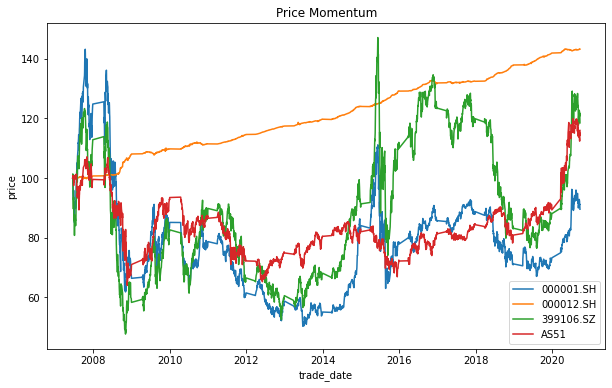

```python
price=rate_daily.dropna(how='any')
price=pd.concat([DataFrame([[100]*4],columns=price.columns,index=[price.index[0]-timedelta(1)]),price])
for i in range(1,len(price)):
    price.iloc[i]=price.iloc[i-1]*(1+price.iloc[i])
for i in price.columns:
    plt.plot(price[i],label=i)
plt.xlabel('trade_date')
plt.ylabel('price')
plt.legend(loc='best')
plt.title('Price Momentum')
```

### 'Price Momentum'即为价格走势图

```python
def create_portfolio(tickers,weights=None):
    if weights is None:
        weights=np.ones(len(tickers))/len(tickers)
    portfolio=DataFrame({'tickers':tickers,'weights':weights})
    portfolio.set_index('tickers',inplace=True)
    return portfolio
```

```python
def objfunvar(weights,returns,target_ret):
    cov=np.cov(returns.T)
    port_var=weights@cov@weights
    return np.sqrt(port_var)
```

```python
def calc_efficient_frontier(returns,sellshort=True):
    result_means = []
    result_stds = []
    result_weights = []

    means = returns.mean()
    min_mean, max_mean = means.min(), means.max()

    nstocks = returns.columns.size
    if sellshort:
        bounds=None
    else:
        bounds = [(0,1) for i in np.arange(nstocks)]
    for r in np.linspace(min_mean, max_mean, 100):
        weights = np.ones(nstocks)/nstocks
        constraints = ({'type': 'eq',
                        'fun': lambda W: np.sum(W) - 1},
                      {'type': 'eq',
                        'fun': lambda W: np.sum(W*means) -r})
        results = scopt.minimize(objfunvar, weights, (returns, r),
                                 method='SLSQP',
                                 constraints = constraints,
                                 bounds = bounds)
        if not results.success: # handle error
            raise Exception(results.message)
        result_means.append(r) # 4 decimal places
        #std_=np.round(np.std(np.sum(returns*results.x,axis=1)),6)
        std_=objfunvar(results.x,returns,r)
        result_stds.append(std_)
        result_weights.append(results.x)
    return {'Means': result_means,
            'Stds': result_stds,
            'Weights': result_weights}
```

```python
rate=rate_monthly.dropna(how='any')
x=calc_efficient_frontier(rate)
x_=calc_efficient_frontier(rate,sellshort=False)
```

```python
loc=x['Stds'].index(min(x['Stds']))
min_std_port=create_portfolio(tickers=price.columns,weights=x['Weights'][loc])
min_std_port.loc['Expected Return']=str(np.round(x['Means'][loc],4))
min_std_port.loc['Std']=str(np.round(x['Stds'][loc],4))
min_std_port
```

| tickers | weights |
| --- | --- |
| 000001.SH | 0.0135 |
| 000012.SH | 0.9626 |
| 399106.SZ | -0.0050 |
| AS51 | 0.0290 |
| Expected Return | 0.003 |
| Std | 0.0035 |

### 以上为允许卖空情况下，最小方差组合的投资权重、预期收益率以及标准差

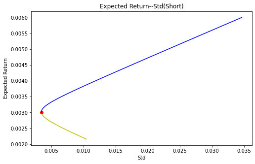

```python
plt.figure(figsize=(8,5))
plt.xlabel('Std')
plt.ylabel('Expected Return')
plt.title('Expected Return--Std(Short)')
plt.plot(x['Stds'][:loc],x['Means'][:loc],'y')
plt.plot(float(min_std_port.loc['Std']),float(min_std_port.loc['Expected Return']),'ro')
plt.plot(x['Stds'][loc:],x['Means'][loc:],'b')
```

### 以上为允许卖空情况，红点为最小方差组合，曲线的蓝色部分即为有效前沿

```python
loc_=x_['Stds'].index(min(x_['Stds']))
min_std_port_=create_portfolio(tickers=price.columns,weights=x_['Weights'][loc_])
min_std_port_.loc['Expected Return']=str(np.round(x_['Means'][loc_],4))
min_std_port_.loc['Std']=str(np.round(x_['Stds'][loc_],4))
min_std_port_
```

| tickers | weights |
| --- | --- |
| 000001.SH | 0.0026 |
| 000012.SH | 0.9645 |
| 399106.SZ | 0.0052 |
| AS51 | 0.0277 |
| Expected Return | 0.0031 |
| Std | 0.0035 |

### 以上为不允许卖空情况下，最小方差组合的投资权重、预期收益率以及标准差

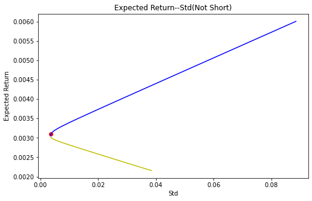

```python
plt.figure(figsize=(8,5))
plt.xlabel('Std')
plt.ylabel('Expected Return')
plt.title('Expected Return--Std(Not Short)')
plt.plot(x_['Stds'][:loc_],x_['Means'][:loc_],'y')
plt.plot(float(min_std_port_.loc['Std']),float(min_std_port_.loc['Expected Return']),'ro')
plt.plot(x_['Stds'][loc_:],x_['Means'][loc_:],'b')
```

### 以上为不允许卖空情况，红点为最小方差组合，曲线的蓝色部分即为有效前沿

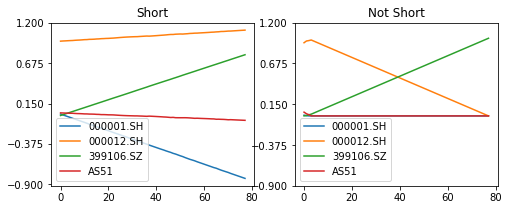

```python
n1=np.min(x['Weights'])
n2=np.max(x['Weights'])
n1-=(n2-n1)/20
n2+=(n2-n1)/20
n1=np.round(n1,1)
n2=np.round(n2,1)
plt.figure(figsize=(8, 3))
ax1=plt.subplot(121)
img1=pd.DataFrame(x['Weights'][loc:])
img1.columns=price.columns
img1.plot(ax=ax1,title='Short')
plt.yticks(np.linspace(n1,n2,5))
ax2=plt.subplot(122)
img2=pd.DataFrame(x_['Weights'][loc:])
img2.columns=price.columns
img2.plot(ax=ax2,title='Not Short')
plt.yticks(np.linspace(n1,n2,5))
plt.show()
```

### 以上分别为允许卖空和不允许卖空情况下，有效前沿中所对应的权重

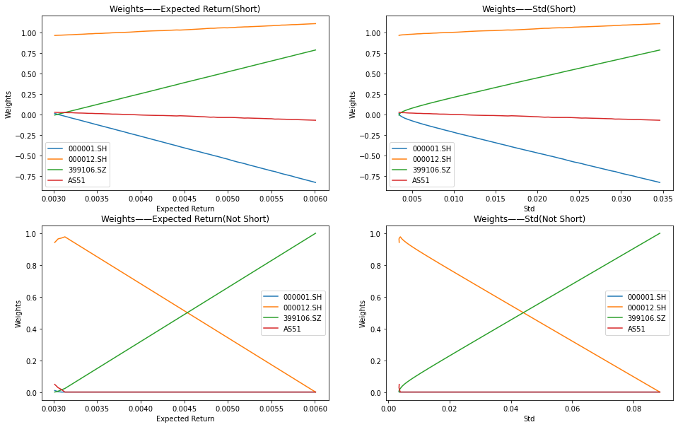

```python
plt.figure(figsize=(16, 10))
ax1=plt.subplot(221)
img1.index=x['Means'][loc:]
img1.plot(ax=ax1,label=["x","y"],title='Weights——Expected Return(Short)')
ax2=plt.subplot(222)
img1.index=x['Stds'][loc:]
img1.plot(ax=ax2,title='Weights——Std(Short)')
ax1.set_xlabel("Expected Return")
ax2.set_xlabel("Std")
ax1.set_ylabel("Weights")
ax2.set_ylabel("Weights")
ax3=plt.subplot(223)
img2.index=x_['Means'][loc:]
img2.plot(ax=ax3,label=["x","y"],title='Weights——Expected Return(Not Short)')
ax4=plt.subplot(224)
img2.index=x_['Stds'][loc:]
img2.plot(ax=ax4,title='Weights——Std(Not Short)')
ax3.set_xlabel("Expected Return")
ax4.set_xlabel("Std")
ax3.set_ylabel("Weights")
ax4.set_ylabel("Weights")
plt.show()
```

### 以上分别为在允许卖空和不允许卖空的情况下，有效前沿中的“权重—预期收益率”图像以及“权重—标准差”图像

```python
df=DataFrame(np.arange(0.003,0.007,0.001),columns=['Expected Return'])
loc0=[]
y={'Means':[]}
t=[]
for i in x['Means']:
    y['Means'].append(np.round(i,4))
y['Stds']=x['Stds']
y['Weights']=x['Weights']
for i in df['Expected Return']:
    loc0.append(y['Means'].index(i))
std=[]
for i in loc0:
    std.append(y['Stds'][i])
df['Std']=std
for i in range(len(rate.columns)):
    l0=[]
    for j in loc0:
        l0.append(y['Weights'][j][i])
    df[rate.columns[i]]=l0
df
```

|  | Expected Return | Std | 000001.SH | 000012.SH | 399106.SZ | AS51 |
| --- | --- | --- | --- | --- | --- | --- |
| 0 | 0.0030 | 0.0035 | 0.0244 | 0.9607 | -0.0153 | 0.0302 |
| 1 | 0.0040 | 0.0117 | -0.2583 | 1.0105 | 0.2514 | -0.0036 |
| 2 | 0.0050 | 0.0226 | -0.5300 | 1.0559 | 0.5084 | -0.0343 |
| 3 | 0.0060 | 0.0342 | -0.8131 | 1.1043 | 0.7755 | -0.0667 |

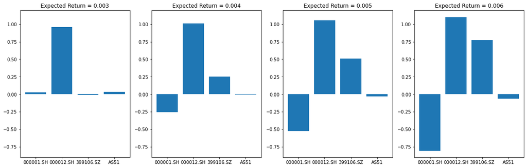

```python
plt.figure(figsize=(20,6))
for i in range(4):
    plt.subplot(int('14'+str(i+1)))
    plt.title('Expected Return = '+str(df.loc[i]['Expected Return']))
    plt.bar(x=rate.columns,height=df.loc[i][rate.columns])
    plt.ylim(-0.9,1.2)
```

### 以上为在允许卖空的情形下，预期收益率每增加千分之一，各资产投资权重变化情况

```python
df=DataFrame(np.arange(0.003,0.007,0.001),columns=['Expected Return'])
loc0=[]
y_={'Means':[]}
t=[]
for i in x_['Means']:
    y_['Means'].append(np.round(i,4))
y_['Stds']=x_['Stds']
y_['Weights']=x_['Weights']
for i in df['Expected Return']:
    loc0.append(y_['Means'].index(i))
std=[]
for i in loc0:
    std.append(y_['Stds'][i])
df['Std']=std
for i in range(len(rate.columns)):
    l0=[]
    for j in loc0:
        l0.append(y_['Weights'][j][i])
    df[rate.columns[i]]=l0
df
```

|  | Expected Return | Std | 000001.SH | 000012.SH | 399106.SZ | AS51 |
| --- | --- | --- | --- | --- | --- | --- |
| 0 | 0.0030 | 0.0043 | 0.0108 | 0.8989 | 0.0000 | 0.0903 |
| 1 | 0.0040 | 0.0275 | 0.0000 | 0.6869 | 0.3131 | 0.0000 |
| 2 | 0.0050 | 0.0568 | 0.0000 | 0.3567 | 0.6433 | 0.0000 |
| 3 | 0.0060 | 0.0874 | 0.0000 | 0.0132 | 0.9868 | 0.0000 |

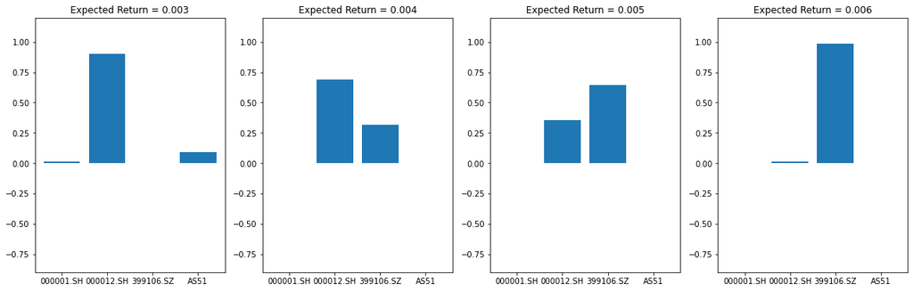

```python
plt.figure(figsize=(20,6))
for i in range(4):
    plt.subplot(int('14'+str(i+1)))
    plt.title('Expected Return = '+str(df.loc[i]['Expected Return']))
    plt.bar(x=rate.columns,height=df.loc[i][rate.columns])
    plt.ylim(-0.9,1.2)
```

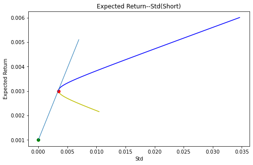

```python
plt.figure(figsize=(8,5))
plt.xlabel('Std')
plt.ylabel('Expected Return')
plt.title('Expected Return--Std(Short)')
plt.plot(x['Stds'][:loc],x['Means'][:loc],'y')
plt.plot(float(min_std_port.loc['Std']),float(min_std_port.loc['Expected Return']),'ro')
plt.plot(x['Stds'][loc:],x['Means'][loc:],'b')
plt.plot(0,0.001,'go')
plt.plot([0,2*x['Stds'][loc+1]],[0.001,2*x['Means'][loc+1]-0.001],linewidth=1)
```

```python
k=np.round((x['Means'][loc+1]-0.001)/x['Stds'][loc+1],4)
b=0.001
'切线组合的方程为y={}x+{},其中x代表方差，y代表预期收益率'.format(k,b)
```

[output not shown]

### 上图中浅蓝色直线表示允许卖空情况下的切线组合

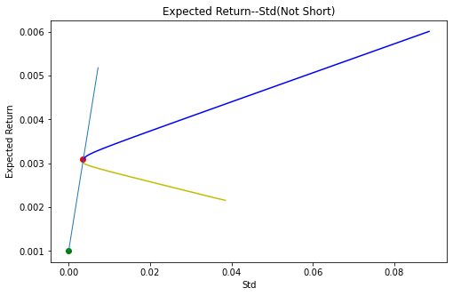

```python
plt.figure(figsize=(8,5))
plt.xlabel('Std')
plt.ylabel('Expected Return')
plt.title('Expected Return--Std(Not Short)')
plt.plot(x_['Stds'][:loc_],x_['Means'][:loc_],'y')
plt.plot(float(min_std_port_.loc['Std']),float(min_std_port_.loc['Expected Return']),'ro')
plt.plot(x_['Stds'][loc_:],x_['Means'][loc_:],'b')
plt.plot(0,0.001,'go')
plt.plot([0,2*x_['Stds'][loc_+1]],[0.001,2*x_['Means'][loc_+1]-0.001],linewidth=1)
```

```python
k=np.round((x_['Means'][loc_+1]-0.001)/x_['Stds'][loc_+1],4)
b=0.001
'切线组合的方程为y={}x+{},其中x代表方差，y代表预期收益率'.format(k,b)
```

[output not shown]

### 上图中浅蓝色直线表示不允许卖空情况下的切线组合